# Extensão e Sociologia Rural

Estudos de Caso em Extensão Rural  
Exemplos Práticos de Ações no Campo

Luiz Diego Vidal Santos

## Visão Geral

### Tópicos Principais

- 1 ATER e Agroecologia no Semiárido
- 2 Programa ABC e Agricultura de Baixo Carbono
- 3 Projeto Silvânia - Embrapa Cerrados
- 4 ATER Quilombola e Indígena
- 5 Extensão Rural e Convivência com a Seca

**Objetivo Central**

Analisar casos práticos de extensão rural no Brasil, avaliando metodologias empregadas, resultados alcançados e lições aprendidas para a formação do engenheiro agrônomo.

## POR QUE ESTUDAR CASOS PRÁTICOS?

A formação do engenheiro agrônomo exige mais do que conhecimento teórico sobre extensão rural. É na **análise de experiências concretas** que se revelam:

- As tensões entre teoria e prática
- As adaptações metodológicas necessárias
- Os fatores que determinam sucesso ou fracasso
- As especificidades regionais e culturais

**Critérios de Análise**

Para cada caso, avaliaremos:

1. Contexto socioambiental
2. Metodologia de extensão adotada
3. Público-alvo e participação
4. Resultados mensuráveis
5. Sustentabilidade da ação

## CASO 1 - AGROECOLOGIA NO SEMIÁRIDO

[figure not shown]

Placa do programa de cisternas ASA no semiárido (CC-BY-SA 3.0 BR, Wikimedia)

**Contexto:** O semiárido nordestino abriga mais de **1,5 milhão** de estabelecimentos da agricultura familiar (IBGE, 2017), enfrentando escassez hídrica crônica e solos degradados.

**Ação:** Programas de convivência com o semiárido, articulados pela ASA (Articulação do Semiárido) e ONGs locais, promovem:

- Cisternas de placa (P1MC - Programa Um Milhão de Cisternas)
- Quintais produtivos agroecológicos
- Bancos de sementes crioulas
- Fossas sépticas biodigestoras

**Metodologia:** DRP (Diagnóstico Rural Participativo) + mobilização comunitária + formação de agricultores-multiplicadores.

## CASO 1 - RESULTADOS E LIÇÕES

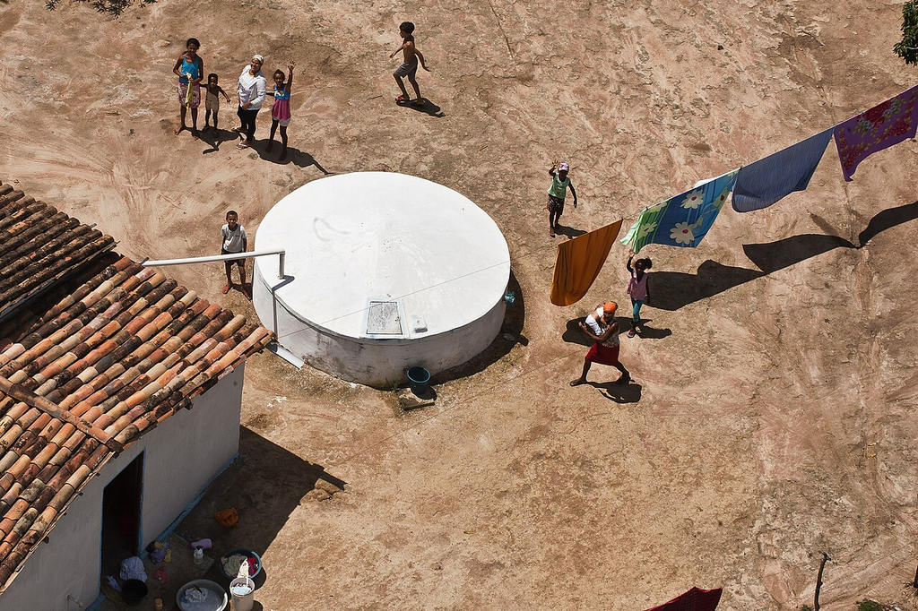

Cisterna de placa em Serrinha/BA (CC-BY-SA 2.0, MDS/Wikimedia)

### Resultados

- Mais de **1,2 milhão** de cisternas construídas até 2023
- Redução da dependência de carros-pipa
- Diversificação da produção para autoconsumo
- Empoderamento das mulheres na gestão hídrica
- Premiação internacional (ONU, FAO)

### Lições para o Agrônomo

- A convivência com a seca é mais eficaz que o combate à seca
- Tecnologias sociais de baixo custo podem ter **grande escala**
- A mobilização comunitária é prerequisito para a sustentabilidade
- O saber local sobre manejo hídrico é complementar ao técnico

> A extensão aqui não é “transferência”, é **construção conjunta** de resiliência (Malvezzi, 2007).

## CASO 2 - PROGRAMA ABC / ABC+

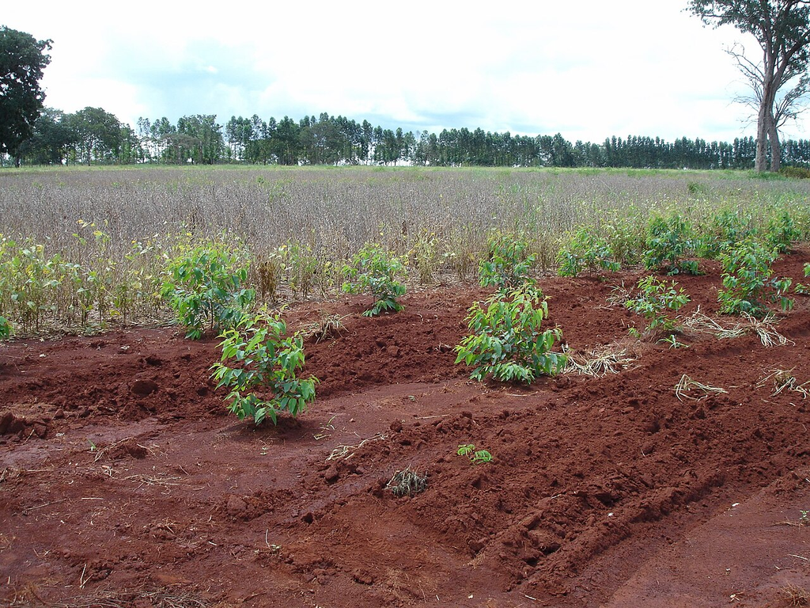

Integração Lavoura-Pecuária-Floresta (iLPF), Cachoeira Dourada/GO (CC-BY-SA 4.0, Túllio F/Wikimedia)

**Contexto:** O Plano de Agricultura de Baixo Carbono (ABC), lançado em 2010 e reformulado como ABC+ em 2021, visa **mitigar emissões de GEE** no setor agropecuário.

**Tecnologias promovidas:**

- Recuperação de pastagens degradadas
- Integração Lavoura-Pecuária-Floresta (iLPF)
- Sistema Plantio Direto (SPD)
- Fixação biológica de nitrogênio (FBN)
- Tratamento de dejetos animais
- Sistemas agroflorestais (SAFs)

**ATER no Programa:** o ABC depende de **extensionistas capacitados** para orientar a adoção dessas tecnologias pelos produtores.

## CASO 2 - O PAPEL DA EXTENSÃO NO ABC

### Desafios de Implementação

A efetividade do Programa ABC está diretamente ligada à capacidade da ATER:

- Alto nível de **conhecimento técnico** requerido (manejo de solo, carbono, integração)
- Necessidade de **planejamento de longo prazo** (5-15 anos)
- Dificuldade de mensuração de resultados (emissões evitadas)
- Acesso ao crédito como gargalo (burocracia bancária)

### Resultados (2010-2023)

- **52 milhões de hectares** de pastagens com algum grau de recuperação
- **17,4 milhões ha** em plantio direto
- **18,7 milhões ha** de iLPF implantados
- Redução estimada de **170 Mt CO₂eq** evitadas

O programa demonstra que a ATER pode ser instrumento de **política climática**, não apenas de produtividade.

## CASO 3 - PROJETO SILVÂNIA (EMBRAPA)

**Contexto:** O Projeto Silvânia, conduzido pela Embrapa Cerrados (DF/GO) nas décadas de 1980-2000, é considerado referência em **pesquisa-desenvolvimento participativa** no Brasil.

**Metodologia em três fases (Zoby e Xavier, 2004):**

1. **Análise e diagnóstico** - levantamento socioeconômico e edáfico das propriedades
2. **Experimentação** - unidades demonstrativas em propriedades selecionadas, com participação ativa dos agricultores
3. **Extensão e difusão** - adaptação das inovações às particularidades de cada produtor

**Diferencial:** a pesquisa não foi conduzida na estação experimental e depois “transferida” - foi **co-construída** com os agricultores desde o início.

## CASO 3 - RESULTADOS E LEGADO

O Projeto Silvânia demonstrou que a integração pesquisa-ATER é possível quando:

- O **agricultor** participa do desenho experimental
- A **propriedade** é a unidade de referência (não a estação experimental)
- Os **indicadores** são definidos conjuntamente (produtividade + renda + qualidade de vida)
- O **tempo** de maturação do projeto é respeitado (mais de 10 anos)

**Legado institucional:** influenciou a criação de metodologias participativas na Embrapa (Projeto Unaí, Projeto Fruticultura Centro-Norte) e reforçou os princípios que posteriormente seriam incorporados à **PNATER** (2010).

## CASO 4 - ATER QUILOMBOLA

**Contexto:** O Brasil possui mais de **6.300 comunidades quilombolas** identificadas (Fundação Palmares, 2023), a maioria no Nordeste, com terras tituladas ou em processo de regularização.

**Desafios específicos:**

- Terras coletivas (não se aplica o modelo individual de ATER)
- Sistemas produtivos baseados em roça de toco, extrativismo e pequena pecuária
- Saberes tradicionais sobre manejo de agrobiodiversidade
- Insegurança territorial (conflitos fundiários)

**Experiência:** Chamadas Públicas de ATER Quilombola (MDA, 2013-2016) contrataram ONGs e cooperativas para oferecer assistência técnica culturalmente adequada.

## CASO 4 - METODOLOGIAS CULTURALMENTE ADEQUADAS

### Princípios da ATER Quilombola

- Respeito ao **calendário produtivo** tradicional
- Valorização dos **sistemas agroflorestais** ancestrais
- Fortalecimento das **organizações comunitárias** locais
- Integração com políticas de **acesso a mercados** (PAA, PNAE)
- Formação de **agentes comunitários de ATER**

### Lições-Chave

A ATER para comunidades quilombolas evidencia que:

- O modelo “universal” de extensão é **insuficiente**
- A escuta ativa é mais importante que o receituário técnico
- O território é **coletivo** - a intervenção deve ser comunitária
- A segurança territorial é pré-condição para qualquer ação produtiva

> Não há ATER eficaz sem **justiça fundiária** (Almeida, 2008).

## CASO 5 - CONVIVÊNCIA COM A SECA EM SERGIPE

**Contexto:** O semiárido sergipano concentra parte significativa dos municípios com baixo IDH do estado. A EMDAGRO (Empresa de Desenvolvimento Agropecuário de Sergipe) e organizações de base atuam na extensão rural local.

**Ações desenvolvidas:**

- Implantação de cisterna de **1ª e 2ª águas** (P1MC + P1+2)
- Manejo sustentável da Caatinga para apicultura
- Quintais produtivos com irrigação por gotejamento simplificado
- Bancos de sementes comunitários (espécies crioulas do semiárido)
- Feiras agroecológicas como canal de comercialização direta

## CASO 5 - INTEGRAÇÃO DE ATORES EM SERGIPE

### Rede de ATER em Sergipe

A experiência sergipana demonstra a importância da articulação:

- **EMDAGRO:** capilaridade municipal e crédito (PRONAF)
- **UFS/IFS:** pesquisa e formação de extensionistas
- **SENAR-SE:** capacitação gerencial
- **ASA/ONGs:** tecnologias sociais e mobilização
- **Prefeituras:** logística e infraestrutura local

### Resultados Observados

- Redução de perdas por estiagem nas propriedades atendidas
- Aumento da diversidade produtiva (até 12 espécies por quintal produtivo)
- Inserção em mercados institucionais (PAA e PNAE)
- Formação de grupos de mulheres produtoras

O caso ilustra que a extensão rural é mais eficaz quando opera em **rede territorial**, não como ação isolada de uma única entidade.

## SÍNTESE COMPARATIVA

| Caso | Região | Metodologia | Público | Resultado Principal |
| --- | --- | --- | --- | --- |
| Semiárido/ASA | Nordeste | DRP + Mobilização | Agricultura familiar | 1,2M cisternas |
| ABC/ABC+ | Nacional | Crédito + AT | Todos | 52M ha pastagens recuperadas |
| Silvânia | Cerrado | Pesquisa participativa | Pequenos produtores | Modelo pesquisa-ATER |
| ATER Quilombola | Nordeste | Culturalmente adequada | Quilombolas | Fortalecimento territorial |
| Convivência (SE) | Sergipe | Rede territorial | Agricultura familiar | Resiliência hídrica |

## CONCLUSÃO

Os casos analisados demonstram que a extensão rural brasileira não admite receitas universais; exige **adaptação metodológica** ao contexto socioambiental, cultural e institucional de cada território.

O engenheiro agrônomo formado pela UFS deve ser capaz de diagnosticar realidades, selecionar métodos participativos, articular redes institucionais e avaliar resultados de modo crítico, sempre com respeito aos saberes locais e às dinâmicas territoriais.

> A extensão rural eficaz é aquela que se torna **desnecessária** - porque empoderou o agricultor a seguir por conta própria.

## REFERÊNCIAS

- Almeida, A. W. B. Terras tradicionalmente ocupadas (2008)
- ASA Brasil. Programa Um Milhão de Cisternas (2023)
- Brasil. Plano ABC - Agricultura de Baixo Carbono (2012)
- IBGE. Censo Agropecuário 2017 (2019)
- Malvezzi, R. Semi-Árido - Uma Visão Holística (2007)
- Zoby, J. L. F.; Xavier, J. H. V. Projeto Silvânia - CPAC/Embrapa Cerrados (2004)
- Brasil. Lei 12.188/2010 - PNATER (2010)

Obrigado!

Luiz Diego Vidal Santos

Universidade Federal de Sergipe (UFS)